# Fast single-cell deep NMF

Zach DeBruine

11/19/2020

# Overview

### Abstract

Single-cell deep NMF (scdNMF) provides an accessible and fast method for deep dimensional reduction of large datasets to learn programs of gene coregulation both within and between single cell experiments. scdNMF extends Seurat functionality by providing a new divisive cell clustering method and deep NMF dimensional reduction method. Unlike previous applications of NMF to single cell datasets, scdNMF is orders of magnitude faster due to warm starts from subsamples, determines optimal rank automatically by stochastic gradient descent and cross-validation, and is robust without regularization due to the density of input matrices. Visualization tools in R are developed for static and interactive exploration of deep dimensional reductions within the resulting Seurat object with an emphasis on coregulation of genes in intracellular, autocrine, and paracrine contexts.

### Part 1: Fast tunable divisive spectral clustering of large single cell count matrices

As a preprocessing step for NMF, massive single cell datasets are desparsified and compressed by fast divisive spectral clustering with subsampling. This approach rivals runtimes of Louvain clustering with PCA reduction. These methods improve upon TooManyCells, a recently published algorithm for fast clustering of millions of cells.

### Part 2: Multi-layer deep NMF with automatic rank determination and warm starts by subsampling

A method is introduced for accelerated k-fold cross validation by gradient descent, and intentional subsampling is used to provide NMF with a warm start. Because of the density of input, NMF can be performed without regularization or Bayesian inference, and is thus very fast. This method is extensible to deep nested decomposition, similar to a deep feed-forward neural network but without backpropagation checks.

### Part 3: Extensible automatic annotation of metagenes with contextual metadata

A computational framework is designed for automatic annotation of metagenes through 1) forward propagation of cell metadata to gene factors, 2) annotation of gene metadata in sets (i.e. RNA type, coding vs. non-coding, spliced vs. unspliced), 3) autocrine and paracrine coupling between sets (using a ligand-receptor database), 4) gene set annotation enrichment in sets.

### Part 4: Graphical visualization package in R for gene-centric analysis

Visualization interfaces for interactive exploration of metagene composition (LDAvis wrapper), and investigation of gene-specific, pathway-specific, and metadata-specific relationships by tree, bipartite network, undirected network, and native Seurat interfaces with support for dynamical metadata-directed pruning.

# Part 1: Efficient tunable divisive spectral clustering of millions of cells

**Motivation:** In-memory clustering of millions of cells can be nearly intractable. Furthermore, when the downstream objective is to solve for coactivated genetic programs, as many clusters as possible are desired and control over cluster count rather than cluster modularity may be ideal. This requires an alternative to the fixed modularity-based clustering methods such as Louvain and TooManyCells. Thus, we devise an approach inspired by that implemented in TooManyCells<sup>[[source](https://www.nature.com/articles/s41592-020-0748-5)]</sup>, the gold standard in efficient clustering of massive datasets. However, we introduce a redesigned theoretical framework, a subsampling strategy, an initially out-of-memory streaming architecture, and substantial performance gains through a sparsity-optimized base R (with Rcpp dependencies) implementation to trivialize clustering of millions of cells.

**Literature precedent:** TooManyCells<sup>[[source](https://www.nature.com/articles/s41592-020-0748-5)]</sup> implements a generalized adaptation of a matrix-free hierarchical spectral-clustering process originally proposed for text mining <sup>[[source](https://static.googleusercontent.com/media/research.google.com/en//pubs/archive/36940.pdf)]</sup>. This algorithm is a fast bipartition spectral clustering, with an elegant stopping criterion based on a zero or negative Newman-Girvan modularity measure.

**Preprocessing:** The algorithm takes as input an *m x n* matrix of *genes x cells* in a Seurat object, normalized using a dataset-appropriate measure, in our case, Seurat SCTransform. In the case of the original publication (which focused on word-based analysis), and in the case of TooManyCells, TD-IDF was applied. However, TooManyCells showed that, regardless of transformation, an accurate and sensitive result was achieved.

*Limitations of TF-IDF*. We do not apply TF-IDF transformation because it rewards cells which naturally express fewer genes and penalizes naive cell types which express many genes. Furthermore, an average of gene importance across all potential clusters is not representative of an average of gene importance between certain specific clusters. Thus, TF-IDF may artificially suppress resolution of some clusters at finer scales.

*SCTransform*. Instead, we use Seurat SCTransform to apply canonical correlation analysis for normalizing gene counts using weights that are based on statistically informative signal as determined by binomial regression. The authors of SCTransform make it abundantly clear how other linear normalization strategies can confound downstream differential expression analyses, rather than help such analyses.

**Similarity measure** TooManyCells uses cosine similarity to cluster cells, which is similar to correlation. The cosine similarity between two vectors `x` and `y` is given by:

$$d_{cos}(x,y) = \frac{{\sum x_iy_i}}{\sum\sqrt{x_i^2}\sum\sqrt{y_i^2}}$$
However, cosine similarity is sensitive to outliers and sparsity. To achieve a more sensitive similarity measure, we adopt a synthesis of both the strengths of an inner product distance (such as the cosine measure) and an overlap-based measure (such as the Jaccard measure). Kumar and Hassebrook <sup>[[source](https://www.osapublishing.org/ao/abstract.cfm?uri=ao-29-20-2997)]</sup> use inner product to measure the Peak-to-correlation energy (PCE) by incorporating an overlap term into the denominator. Inuitively, single cell data is pseudo-binary in that unnormalized counts comprise a zero-inflated and very narrow Poisson distribution. The PCE similarity measure is more robust to sparsity due to a dependence on both inner product and overlap, not inner product alone. The PCE (or Kumar-Hassebrook) similarity is defined as:

$$d_{PCE}(x,y) = \frac{{\sum x_iy_i}}{\sum x_i^2 + \sum y_i^2 - \sum x_iy_i^2}$$
Interestingly, when `x` and `y` are binary (all values either 0 or 1), PCE is related to the Jaccard measure by:

$$d_{PCE}(x,y) = 1 - d_{Jaccard}(x,y)$$

Thus, PCE similarity is essentially a binarized Jaccard distance applied to non-binary data.

This formula is implemented in ParallelDist in R as an RccpXPtrUtils function, and achieves performance nearly equivalent to that of Cosine distance. This implementation is multithreaded vector-wise in Rcpp with sparse optimization while TooManyCells is single-threaded and run on the command-line implicitly in the matrix.

*UPDATE:* It turns out that PCE is less sensitive than cosine similarity for cells. Also, parallelDist takes as input a dense matrix while wordspace can parallelize cosine calculations on sparse matrices with highly efficient vector operations. Thus, cosine similarity wins by a landslide both in terms of speed and information. However, when dealing with gene x gene coexpression in small latent spaces, PCE is superior in constructing a gene similarity matrix.

Thus, we iteratively bipartition the set using rank-2 SVD with IRLBA. This avoids the computational cost of computing the Laplacian and running rank-2 SVD on the laplacian. It seems that the Laplacian gives the same partitioning as the similarity.

**Subsampling for bipartitioning:** For tens of thousands of cells, computing a `cell x cell` similarity is computationally prohibitive. To this end, in TooManyCells (and the original spectral bipartitioning publication), a type of cell-wise similarity was computed in an implicit matrix-free manner by taking advantage of a property of a Laplacian normalized matrix form. This matrix-free approach was taken because when `n >> m`, it is faster to perform clustering without explicitly solving for a n x n similarity while avoiding excessive memory requirements. However, we propose to use subsamples of `m/m_0` for bipartitioning, thus when `n < m_0`, it is faster to explicitly solve for a similarity of `m_0 x m_0` than an implicit Laplacian from a type of similarity on `m x n`.

Subsampling is implemented as follows. Given a matrix of `genes x cells`, select `n` cells as representatives of the general population. Compute the similarity for `m_0 x m_0`, and bipartition with rank-1 SVD. Compute cluster centroids, then assign cells to centroids based on cosine similarity to the centroid. Thus, bipartite cluster assignment for a given cell `c_k` to either centroid `C1` or `C2` is given by:

$$d_{cos}(c_i,C_1,C_2) = d_{cos}(cell_i,C_1) - d_{cos}(cell_i,C_2)$$
$$C(i) = \left\{\begin{array}
{rr}
1, \ d_{PCE}(c_i,C_1,C_2) \geq 0 \\
2, \ d_{PCE}(c_i, C_1, C_2) < 0 \\
\end{array}\right.$$

This calculation involves vector operations on a `2 x n.cells` matrix, and thus is extremely fast and scalable to millions of cells. Obviously, this calculation can be parallelized batch-wise, but the advantages are on the order of milliseconds except for tens of millions of cells.

**Stopping criteria:** Bipartitioning can iterate until clusters are no longer divisible based on a Newman-Girvan edge betweenness modularity measure. While the Newman-Girvan modularity measure is not the cheapest computational solution, it is the most relevant. For instance, Kullback-Leibler divergence (with a specified tolerance) requires non-zero probabilities for all coefficients (which is not the case), and cosine similarity assumes all clusters that are indivisible have equidistant centers, which is not true. To control the amount of clusters, the stopping criteria dependent on the Newman-Girvan modularity can be adjusted to positive (fewer clusters) or negative (more clusters) relative to maximum modularity for each bipartition. A second optional stopping criteria is also imposed for the minimum number of cells divided for any given bipartition. In the vast majority of cases, Newman-Girvan modularity will trigger stoppage first, but this second criteria is useful to avoid overly sparse clusters which will confound further dimensional reduction by NMF.

The function for Newman-Girvan modularity as implemented in the iGraph `modularity` function is:

$$Q = \frac{1}{2m} \sum_{i,j} \left( \left(A_{ij} - \frac{k_ik_j}{2m}\right) \ \delta(c_i,c_j) \right)$$
where m is the number of edges, Aij is the element of the A adjacency matrix in row i and column j, ki is the degree of i, kj is the degree of j, ci is the type (or component) of i, cj that of j, the sum goes over all i and j pairs of vertices, and delta(x,y) is 1 if x=y and 0 otherwise.

This is the equation for Newman-Girvan modularity of a continuous similarity:

$$Q(C_1,C_2) = \sum_{k=1}^2 \left( \frac{O_{kk}}{L} - \left( \frac{L_k}{L}\right) ^2\right)$$

where
$$O_{kk}=∑_{i∈C_k,j∈C_k}A(i,j)$$
is the total degree of nodes in cluster
$$C_k$$
, if
$$d_i=\sum_{j=1}^m A(i,j)$$
is the degree of node `i` then
$$L_k=\sum_{i∈Ck}d_i$$
is the total degree of nodes in
$$C_k$$
, and
$$L=\sum_{i=1}^m d_i$$
is the degree of all nodes in the network. `Q` measures the distance of edges within clusters to the random distribution of clusters, such that `Q > 0` denotes non-random communities and `Q ≤ 0` demonstrates communities randomly found. (source: TooManyCells)

**Parallelization:** Because each bipartite division is computed on a single core, the higher-order divisions can be parallelized across multiple cores. This is a bit complicated, but can probably be done best with mclapply.

**Algorithm implementation:** Thus, we have a fast method for divisive clustering on potentially tens of millions of cells:

Preprocessing. The datasets are individually normalized against a reference with Seurat SCTransform using label transfer. Each dataset is stored separately as a sparse matrix. This is by far the most computationally expensive step. 1. Subsamples are pulled from each dataset of size `subsample*nsamples` 2. A similarity is computed across all samples 3. The similarity is bipartitioned with rank-2 SVD 4. Cluster centroids are computed as means of subsampled cells 5. Edge betweenness is computed between both centroids, if less than `mod.tol`, designate the parent node as a leaf node 6. Assign all cells in parent cluster to one of the two children clusters based on similarity to cluster centers. 7+. Repeat steps 1 to 6 for all non-leaf children nodes after computing all parent nodes at that generation.

Finally, assign cell Idents in the Seurat object to cluster names. To enable assignment of cells to multiple clusters, create a separate Idents object for each generation. If a cell has no assignment in that generation, assign it to it’s leaf node cluster.

Of interest, Seurat AverageExpression() may be run on the active Idents (leaf node clusters)

# Application of Part 1 to PBMC 3K dataset

We’ll write a FindClusters.Divisive() function where we perform bipartite divisive clustering with subsampling with the Seurat PBMC 3K dataset.

### Load data and normalize

Here SCTransform is used to normalize the data. Standard log-normalization or TF-IDF may be performed, but do not yield results which are as clean as SCTransform.

```r
library(Seurat)
library(SeuratData)
InstallData("pbmc3k")
data("pbmc3k")
pbmc <- SCTransform(pbmc3k, verbose = 0)
```

### Step 1: Pull subsamples from data

```r
subsample.size <- 1000 # size to subsample if number of cells is greater than this
pbmc.subset <- pbmc[,sample(1:ncol(pbmc),subsample.size)] # subset object with subsample.size randomly selected cells
```

### Step 2: Compute cosine similarity across all samples

Compute cosine similarity on the sparse SCT assay counts slot with `wordspace`, an unrivaled Rcpp implementation of cosine similarity calculation for sparse matrices with very fast vector operations.

`wordspace` can also be parallelized with openmp, but for matrices of less than ten thousands of cells (as we have here) the gains are needlessly marginal.

```r
library(wordspace)

# use counts from the active assay
counts <- GetAssayData(object = pbmc.subset, slot = "counts")

cells.cosine.similarity <- dist.matrix(counts, byrow = FALSE, method = "cosine", convert = FALSE)
#diag(cos) <- 0
```

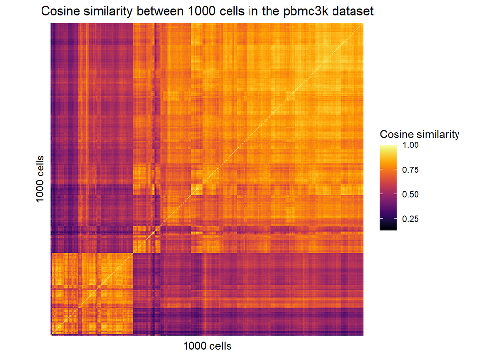

### Step 3: Bipartition of the similarity with rank-2 SVD

```r
# run rank-1 SVD on cells.cosine.similarity similarity with irlba where nv = 2 and nu = nv
library(irlba)
svd <- irlba(cells.cosine.similarity, nv = 2)
```

Notice that the second vector provides informative positive and negative signal:

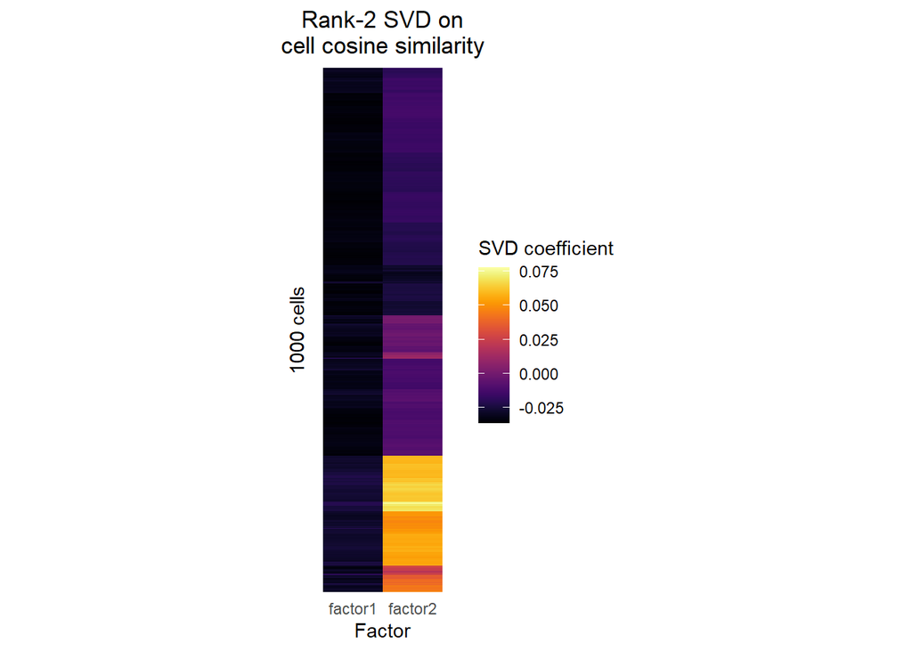

There is a natural approximate bipartition about 0:

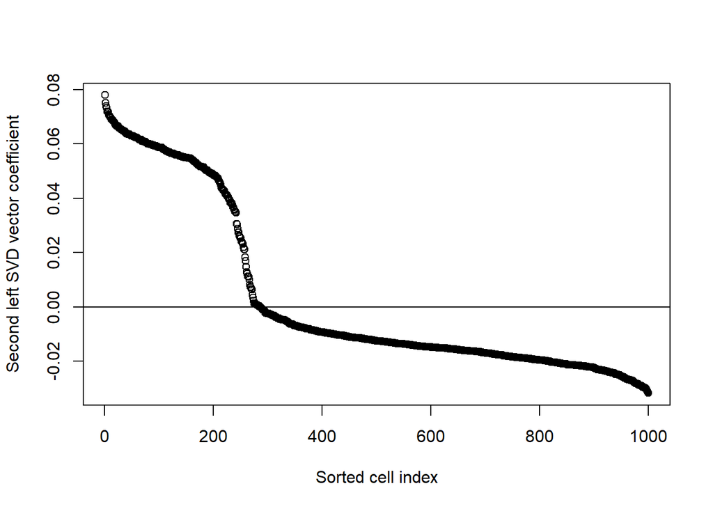

Also note that `svd$u[,2] == svd$v[,2]`:

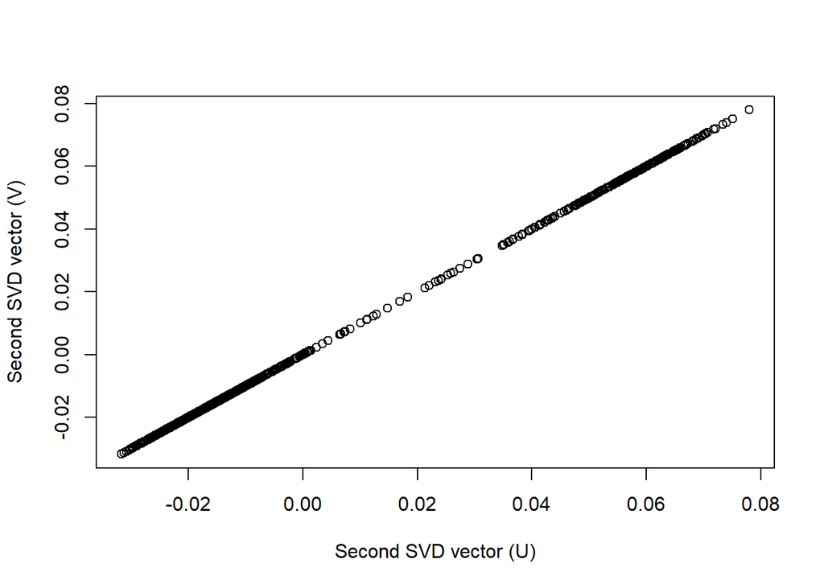

We can also compute the normalized laplacian of the similarity matrix as

$$L(S) = diag(colsums(S)) - S$$

where `S` is `cells.cosine.similarity`.

```r
L.cells.cosine.similarity <- diag(colSums(cells.cosine.similarity)) - cells.cosine.similarity
diag(L.cells.cosine.similarity) <- 0
L.svd <- irlba(L.cells.cosine.similarity, nv = 2)
```

When we run SVD on the laplacian we get results identical to those obtained previously:

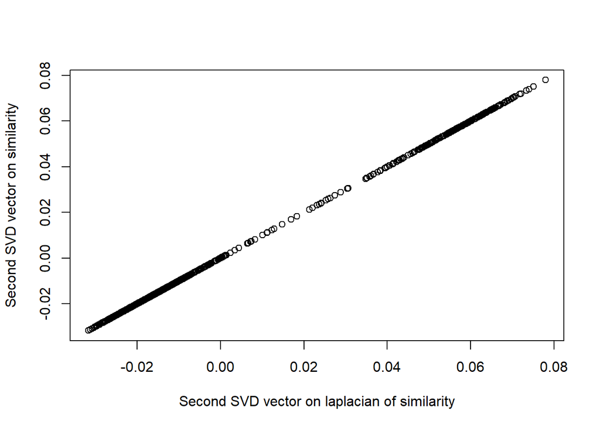

Thus, it is not necessary to calculate the laplacian as is done in TooManyCells and we can spare the computational expense associated with that calculation. Rather, we can simply use the second largest vector from SVD on the similarity itself.

Now assign cells to cluster 1 or cluster 2 based on sign in the second SVD vector:

```r
vector <- svd$u[,2]
names(vector) <- rownames(cells.cosine.similarity)
cluster1.cellnames <- names(which(vector>=0))
cluster2.cellnames <- names(which(vector<0))
```

### Step 4: Cluster centers are computed as means of subsampled cells

```r
# average the counts of cells in cluster1 and cluster2
centers <- cbind(
  "c1" = rowMeans(pbmc.subset[,cluster1.cellnames]),
  "c2" = rowMeans(pbmc.subset[,cluster2.cellnames])
)
```

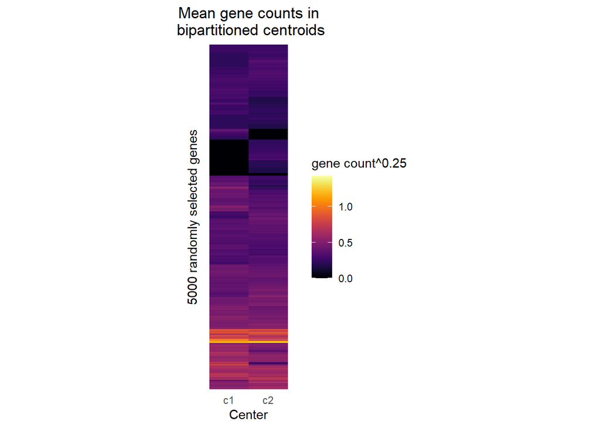

### Step 5: Cosine similarity between both centroids is calculated and is a potential stopping criteria

*Note:* This step is (hopefully) only relevant later on when we perform multiple iterations. This stopping criteria replaces Newman-Girvan modularity (which involves an NP-hard calculation rather than a fast element-wise vector multiplication on a log ratio).

*UPDATE:* This needs to be updated to Newman-Girvan modularity using the iGraph `modularity` function.

```r
R2.tol <- 0.95 # stop when the correlation between clusters is greater than 0.95
centers.R2 <- cor(centers[,1],centers[,2])
if(centers.R2 > R2.tol){
  break
}
centers.R2
```

```
## [1] 0.8950715
```

### Step 6: Assign cells in each dataset to one of two clusters based on similarity to centroids

For efficiency, in this step, we use cosine similarity as these vector operations are extremely fast. Note that it is even faster for sparse matrices and does not require desparsification at any point in the calculation.

```r
# compute cosine similarity between all cells (columns) in A and both centroids
library(wordspace)
cos <- dist.matrix(centers, counts, byrow = FALSE, convert = FALSE, method = "cosine")
clusters <- apply(cos, 2, which.max)

# generate new count matrices for each cluster
counts1 <- counts[,names(clusters[clusters == 1])]
counts2 <- counts[,names(clusters[clusters == 2])]
```

### Step 7: Repeat steps 1-6 for each bipartition until step 5 breaks the loop

```r
#' An instance of bipartite spectral clustering of cells based on cosine similarity across gene profiles
#'
#' @param data A sparse matrix of class dgCMatrix with genes in rows and cells in columns
#' @param subsample.size Number of cells to subsample for each clustering iteration. Defaults to 1000.
#' @param R2.tol Maximum permitted R2 value between cluster centroids
#' @returns A list of cells in either cluster and the cosine distance between the two cluster centers
bipartite.cluster <- function(data, subsample.size = 1000, seed = NULL){

  if(!is.null(seed)) set.seed(seed)

  # subset object with subsample.size randomly selected cells
  ifelse(subsample.size > 100 && ncol(data) > subsample.size,
         data.subset <- data[,sample(1:ncol(data), subsample.size)],
         data.subset <- data)

  # compute cosine similarity between all cells in data.subset
  cosine.sim <- dist.matrix(data.subset, byrow = FALSE, method = "cosine", convert = FALSE)

  # run left-truncated SVD with IRLBA and extract the second largest vector (u == v, so it doesn't matter which)
  u2 <- irlba(cosine.sim)$u[,2]
  names(u2) <- rownames(cosine.sim)

  # assign cells to a cluster by the sign of the second singular vector
  centers.cells <- list(names(which(u2 >= 0)), names(which(u2 < 0)))

  # calculate centers as the mean of all cells in each cluster
  centers <- cbind(rowMeans(data.subset[,centers.cells[[1]]]), rowMeans(data[,centers.cells[[2]]]))

  # if the cells used to generate the clusters were a subset of the cluster:
  if(ncol(data.subset) != ncol(data)){
    # compute cosine similarity between all cells in the input data matrix and the determined cluster centers
    cos <- dist.matrix(centers,data, byrow = FALSE, convert = FALSE, method = "cosine")

    # now assign each cell to a cluster based on the cluster to which it has maximum cosine similarity
    clusters <- apply(cos, 2, which.max)

    # put this in a list as before
    centers.cells <- list(names(clusters[clusters==1]), names(clusters[clusters == 2]))
  }

  # compute cosine similarity between both centers
  center.similarity <- cosine.sim(centers[,1],centers[,2])

  return(list(centers.cells[[1]], centers.cells[[2]], "dist" = 1 - center.similarity))
}

#' Run recursive bipartite clustering by spectral decomposition and update Seurat object with cluster assignments
#'
#' @param data Seurat object, the default assay counts slot will be used
#' @param rsq.tol The minimum cosine distance permitted two cluster centers
#' @param min.cells The minimum number of cells permitted in a cluster
#' @param subsample.size The maximum number of cells to sample for determining cluster centers
#' @param convert.to.sparse If `data` is not a sparse matrix, convert to sparse. Critical for speed gains.
#' @returns A Seurat object where object@ident has been updated with new cluster info. object@all.idents is created with cell assignments to all clusters, where cluster names are given by a sequence of 1 and 2 corresponding to bipartite splits, and leaf clusters names are terminated with a 0
FindClusters.Divisive <- function(seuratObj, stop.tol = 0.05, min.cells = 10, subsample.size = 1000, seed = NULL, convert.to.sparse = TRUE){
  library(Matrix)
  library(wordspace)
  library(irlba)
  library(Seurat)

  # To do:
  # 1. Add in optional Newman-Girvan modularity stopping criteria in addition to cosine dist stopping criteria
  # 2. Add in txt progress bars for each generation in place of cat output
  # 3. Add in overall summary message after clustering is finished, along with runtime

  # load data from the "counts" slot of the default assay of the given Seurat object
  data <- GetAssayData(object = seuratObj, slot = "counts")

  if(convert.to.sparse == TRUE){
    data <- Matrix(data, sparse = TRUE)
  }

  # run bipartite.clustering on the initial dataset
  first.split <- bipartite.cluster(data, subsample.size = subsample.size, seed = seed)
  nodes <- list("1" = first.split[[1]], "2" = first.split[[2]])
  if(first.split$dist < stop.tol){
    warning("Cosine distance between the first two centroids was less than stop.tol. Try increasing stop.tol.\n\n")
  }else{
    prev.iter.nodes <- c("1","2")
    while(length(prev.iter.nodes > 0)){
      iter.nodes <- c()
      for(i in 1:length(prev.iter.nodes)){
        node.name <- prev.iter.nodes[i]
        node.cells <- data[,nodes[[node.name]]]
        # node.cells should contain greater than min.cells
        node.children <- bipartite.cluster(node.cells, subsample.size = subsample.size, seed = seed)
        # implement edge betweenness from the igraph package as a Newman-Girvan modularity measure for stopping point, rather than cosine distance
        if(node.children$dist > stop.tol && min(length(node.children[[1]]),length(node.children[[2]])) > min.cells){
          nodes[[paste0(node.name,"1")]] <- node.children[[1]]
          nodes[[paste0(node.name,"2")]] <- node.children[[2]]
          iter.nodes <- c(iter.nodes, paste0(node.name,"1"), paste0(node.name,"2"))
        } else{ # add a 0 to the node name to designate it as a leaf node
          nodes[[paste0(node.name,"0")]] <- nodes[[node.name]]
          nodes[[node.name]] <- NULL
        }
      }
      prev.iter.nodes <- iter.nodes
    }
  }

  for(i in 1:length(nodes)){
    # not sure it will work to assign a cell to multiple idents. In that case, just create new idents object for each level
    Idents(object = seuratObj, cells = nodes[[i]]) <- names(nodes)[[i]]
  }
  # stash these idents as all.idents
  seuratObj[["all.idents"]] <- Idents(object = seuratObj)

  # now get leaf nodes and set as active idents
  substrRight <- function(x) substr(x, nchar(x), nchar(x))
  substrLeft <- function(x) substr(x, 0, nchar(x)-1)
  for(i in 1:length(nodes)){
    if(substrRight(names(nodes)[i])=="0"){
      Idents(object = seuratObj, cells = nodes[[i]]) <- substrLeft(names(nodes)[[i]])
    }
  }
  return(seuratObj)
}

cosine.sim <- function(x,y){
  x %*% y / sqrt(x%*%x * y%*%y)
}
```

Now that we can run this function on the pbmc3k dataset and compare with the Seurat `FindClusters()` function.

Note that the FindClusters.Louvain() function requires centering and scaling of the data while FindClusters.Divisive() does not. This is because divisive clustering is performed on a similarity matrix. Centering and scaling the original full dataset takes a significant amount of time.

Further note that FindClusters.Louvain() requires the user to specify a number of significant principal components. This is non-trivial. Here we adopt the conclusion of the pbmc/Seurat authors that the ideal number of principal components is 10 for the pbmc dataset.

Finally, Louvain clustering with Seurat FindClusters() requires a resolution hyperparameter to determine the modularity cutoff. In turn, FindClusters.Divisive() requires a stop.tol to determine when to stop dividing clusters.

```r
FindClusters.Louvain <- function(pbmc, num.pcs = 10, resolution = 1){
  pbmc <- ScaleData(pbmc, features = rownames(pbmc))
  pbmc <- RunPCA(pbmc, features = VariableFeatures(object = pbmc), npcs = 30)
  pbmc <- FindNeighbors(pbmc, dims = 1:num.pcs)
  pbmc <- FindClusters(pbmc, resolution = resolution)
  pbmc
}

library(rbenchmark)
benchmark("divisive" = {
            pbmc.divisive <- FindClusters.Divisive(pbmc, stop.tol = 0.05)
          },
          "louvain" = {
            pbmc.louvain <- suppressWarnings(suppressMessages(
              FindClusters.Louvain(pbmc, num.pcs = 10, resolution = 1))
            )
          },
          replications = 1,
          columns = c("test", "replications", "elapsed", "relative", "user.self", "sys.self")
        )
```

[output not shown]

```
##       test replications elapsed relative user.self sys.self
## 1 divisive            1    3.64    1.000      3.36     0.27
## 2  louvain            1    6.14    1.687      5.78     0.36
```

Now let’s view what these clusters look like on a UMAP plot:

```r
pbmc.divisive <- RunPCA(pbmc.divisive, verbose = FALSE)
pbmc.divisive <- RunUMAP(pbmc.divisive, dims = 1:15, verbose = FALSE)

pbmc.louvain <- RunUMAP(pbmc.louvain, dims = 1:15, verbose = FALSE)
```

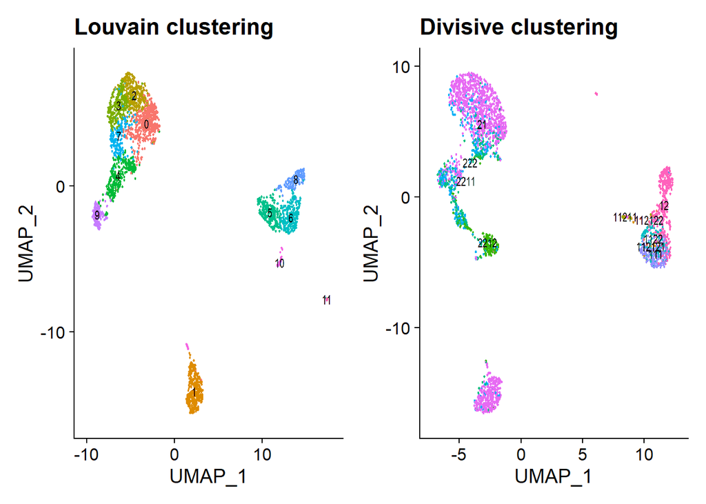

# Application of part 1 to developmental stages in the Mouse Organogenesis Cell Atlas

We aim to apply the techniques discussed in part 1 to the Mouse Organogenesis Cell Atlas, a dataset of 1.2 million cells from whole mouse embryos between E9.5 and E13.5 embryos, distributed across 24 hour increments. We will cluster cells from each developmental time point separately, and then merge clusters prior to NMF. This prevents any mixing of developmental stage-specific information across highly similar cell times.

### Run SCTransform on matrices of cells from each developmental stage:

```r
# download files "gene_count_cleaned.rds", "cell_annotate.csv", and "gene_annotate.csv" from:
# https://oncoscape.v3.sttrcancer.org/atlas.gs.washington.edu.mouse.rna/downloads
library(monocle)
data <- readRDS("gene_count_cleaned.RDS")
data <- as.matrix(data)

# convert to short gene name (made unique)
gene_names <- read.csv("gene_annotate.csv")
gene_names$gene_short_name <- make.unique(as.character(gene_names$gene_short_name))
rownames(data) <- gene_names$gene_short_name

# sort data by developmental stage (E9.5, E10.5, E11.5, E12.5, E13.5)
cell_data <- read.csv("cell_annotate.csv")[,c("sample","development_stage")]
stages <- unique(cell_data$development_stage)
data_stage <- list()
for(i in 1:length(stages)){
    cellnames <- as.vector(cell_data[cell_data$development_stage == stages[i],]$sample)
    data_stage[[paste0("E",stages[i])]] <- data[,intersect(colnames(data),cellnames)]
}

# save files for each stage
for(i in 1:length(data_stage)){
    saveRDS(data_stage[[i]],paste0(names(data_stage)[i],".rds"))
}

# run SCTransform on each file and save Seurat object
library(Seurat)
library(future)
plan("multiprocess", workers = 40)
options(future.globals.maxSize = 75000 * 1024^2)

stages <- c("E9.5","E10.5","E11.5","E12.5","E13.5")
for(i in 1:length(stages)){
    s <- readRDS(paste0(stages[i],".rds"))
    s <- CreateSeuratObject(counts = s)
    s <- SCTransform(s, variable.features.n = 3000, ncells = 50000, do.center = FALSE)
    saveRDS(s, paste0(stages[i],"_seurat.rds"))
}
```

Now we can load the files for clustering with `FindClusters.Divisive()` when ready.

# Part 2: Fast NMF with warm starts by subsampling and automatic rank determination by cross-validation

**Motivation:** NMF on large matrices is computationally expensive. Furthermore, finding the optimal rank for k by k-fold cross validation is an expensive process. We propose a method to drastically accelerate factorization of the full matrix at optimal rank k by 1) introducing a strategy for a warm start from an intentionally selected subsample of features, 2) proposing a less expensive method for determining optimal rank k, and 3) employing gradient descent to converge on optimal rank k.

**Preliminaries on literature precedent: NNDSVD is not always good head start for NMF:** Non-negative double SVD has previously been proposed as a method for initializing NMF factorizations. In NNDSVD, it is assumed that the method of variance explanation in SVD translates to a meaningful initialization for NMF that is along a continuum towards the global minimum. However, SVD in itself represents a highly contained local minimum, and thus NNDSVD presents NMF with a local minimum with a dangerously high initial activation energy which may be impossible to surmount due to the complex patterns of sparsity in the provided factors. Indeed, NMF rarely improves on the objective compared to the NNDSVD initialization, while it can dramatically improve (both in terms of sensitivity and accuracy) on the objective when given a random start.

**A subsetting strategy for giving NMF a head start:** Since NMF on a large matrix is difficult, start with a small matrix that encapsulates the diversity of the input matrix. Use this subset to determine an optimal rank k, then use that NMF model as a warm start for a second factorization on a larger subset, etc.

**Random subsetting of the data:** We capture the diversity of the dataset by determining a set of genes which collectively represent the diversity of the dataset. This is done by running left-truncated SVD on the input, selecting significant factors based on robustness, and then selecting the first `n_1` genes from the top and bottom of each significant vector.

**Unsupervised determination of the number of consecutive left-sided robust factors in SVD:** A common method for selecting a number of consecutive left SVD factors to keep is based on the “Elbow method” (scree plot), other methods invoke modularity measures or permutation. However, these methods are somewhat subjective and tend to underestimate robust signal. To find factors encoding robust variance, we run SVD on two subsets of the data with non-overlapping genes and entirely overlapping cells, thus these subsets share cells but not genes. We then perform bipartite matching of the `V` matrix (cells), assuming that robust factors are represented on a one-to-one basis in order along the diagonal. When matched factors no longer occur at the same index in the diagonal, it indicates that contaminating noise has masked the biologically relevant information in the factor. Rather than exercise a hard cutoff at the first instance of diagonal mismatch, we specify a tolerance, based on the cumulative deviance from one-to-one matching along the diagonal. In general, the number of significant factors in this approach coincides with a factor just after the visually apparent inflection point on a scree plot. After selecting a number of factors to keep, genes may be chosen from these factors for downstream analysis.

The optimal k determined from SVD is also saved as an initial k for NMF factorization.

This method is outlined in a separate Rmarkdown document.

**Initialize the NMF model with an intentionally selected subset of genes:** Run NMF with all metacells and selected genes at multiple rank k, guided by gradient descent with a conservative learning rate, and measure standard error of missing value imputation at each k, beginning with the k determined to be optimal for SVD of the genes on the input matrix. Use the efficient ANLS NNLM algorithm without regularization, and a high convergence tolerance during the optimization steps. For initial determination of rank k, use only a single set of missing values. Then test another `k` sets of missing values, each time stepping away from the average minima to determine any deviation from the average minima by weighted averaging of each consecutively learned minima.

**Model building with warm starts:** After NMF on a subset of data at the optimal rank k, we now select `n_2` genes from the dataset, taking genes which are most similar to the genes already factorized and initializing each new gene with weights of the gene with which it is most similar. NMF converges very quickly with each iteration because the results are nearly correct. We repeat k-fold cross validation, stepping away from the local minima in either direction. If the minima has not changed, the cross-validation procedure is stopped early.

This procedure is repeated until all genes have been added to the model. After adding the final half of genes, no missing values are held out and the matrix is factorized in its entirety at the consensus best k.

Note that this same subsetting procedure can be also be adapted for hyperparameter tuning against an objective function.

```r
fast.nmf <- function(A, alpha = rep(0,3), n.threads = 0, verbose = 3, k.initial = 5){
  # cluster genes
  # get leaf node eigengenes
  # run NMF on eigengenes and cells at k = 5
  # knock out 5% of the values
  # measure standard error of missing value imputation
  # step higher until no longer decreases,
  # optimal k?
  # now try new missing values
}
```

```r
library(parallelDist)
library(RcppXPtrUtils)
library(RcppArmadillo)

# Compute similarity with the peak to correlation energy (PCE) measure, implemented in the parallelDist package as a custom RcppXPtr function.
# when running the function for the first time, about 2 seconds are needed to compile
pce.similarity <- function(m){
    d <- parallelDist(
      m,
      method = "custom",
      func = cppXPtr("double customDist(const arma::mat &A, const arma::mat &B) {return (1 - arma::accu(A % B)/(arma::accu(arma::square(A)) +
                     arma::accu(arma::square(B)) - arma::accu(arma::square(A % B))));}", depends = c("RcppArmadillo"))
    )
    d <- as.matrix(d)
    diag(d) <- 0
    d
}

# wordspace supports sparse distance calculations, and has a highly efficient cosine similarity calculation.
# take counts from the SCT-normalized slot and run pce.similarity
pbmc.pce <- pce.similarity(GetAssayData(object = pbmc.subset[["SCT"]], slot = "counts"))
hist(A0.pce)
```

[output not shown]

** Deep NMF for learning abstractive gene coactivation similarities:** Run Fast NMF recurrently on gene x metagene matrices to yield increasingly high-level communities of coactivated genes.

### Part 3: Extensible automatic annotation of metagenes with cell and gene metadata

A computational framework is designed for automatic annotation of metagenes through 1) forward propagation of cell metadata to gene factors, 2) annotation of gene metadata in sets, 3) autocrine and paracrine coupling between sets, 4) Gene Ontology term enrichment in sets.

### Part 4: Graphical visualization package in R for gene-centric analysis

Visualization interfaces for overall analysis of metagenes, and for understanding gene-specific, pathway-specific, and cell-specific activities. Build on LDAvis, BirchBeer (from TooManyCells package), iGraph, and ggplot2 packages.